# Analysis v3

This notebook analyses the data loaded, recoded and explored in (1) `load.Rmd` and (2) `explore.Rmd`.

```r
df <- read_csv(paste0(root_path, "/data/v3/pulse/df-pulse.csv"), col_types = cols(pulse = "c", pulse_group = "c"))
```

Base profile

```r
df %>% view("df")
df %>% skimr::skim()
```

So, 69% of all rows are pulsing - but that doesn’t mean that 69% of 2021 pulsing happened, rather that 69% of all events in 21 were pulsing events.

# Objectives and questions

Key objective is to learn about pulse cooling and how it effects temperature. Some questions of interests:

## Length

- How long are pulse cooling periods?

## Rate of change

- What is the rate of temperature change during pulse cooling?
- Does it change during the pulse cooling phase?

## Frequencies

- What is the modulation frequency during pulse cooling?
- Does it change and if so how?
- Do different frequencies impact temperature differently?

## Split

- Fermentation vs no fermentation

# Recode

## Status label

`status` categories are:

- 0 Loss of data or error
- 1 Tank is off
- 2 Tank is on but not cooling
- 3 Tank is on and cooling
- 10 No ROC alarm low temperature alarm (valve closed - not cooling)
- 11 No ROC alarm low low temperature alarm (valve closed - not cooling)
- 12 No ROC alarm high temperature alarm ~2 (valve open - cooling)
- 13 No ROC alarm high high temperature alarm ~10 (valve open - cooling)
- 14 In ROC alarm low temperature alarm (valve closed - not cooling)
- 15 In ROC alarm low low temperature alarm (valve closed - not cooling)
- 16 In ROC alarm high temperature alarm (valve open - cooling)
- 17 In ROC alarm high high temperature alarm (valve open - cooling)

Let’s create a label column for `status`:

```r
# Check
df %>%
  mutate(status_label = case_when(
    status == 0 ~ "error",
    status == 1 ~ "off",
    status == 2 ~ "on - not cooling",
    status == 3 ~ "on - cooling",
    status == 10 ~ "low temp alarm - not cooling",
    status == 11 ~ "low low temp alarm - not cooling",
    status == 12 ~ "high temp alarm - cooling",
    status == 13 ~ "high high temp alarm - cooling",
    status == 14 ~ "low temp alarm - not cooling",
    status == 15 ~ "low low temp alarm - not cooling",
    status == 16 ~ "high temp alarm - cooling",
    status == 17 ~ "high high temp alarm - cooling",
  )) %>%
  group_by(status, status_label) %>%
  count()
```

| status | status_label | n |
| --- | --- | --- |
| 1 | off | 3019 |
| 2 | on - not cooling | 15350 |
| 3 | on - cooling | 11324 |
| 10 | low temp alarm - not cooling | 17 |
| 11 | low low temp alarm - not cooling | 1628 |
| 12 | high temp alarm - cooling | 25 |
| 13 | high high temp alarm - cooling | 12 |
| 15 | low low temp alarm - not cooling | 479 |
| 16 | high temp alarm - cooling | 51 |
| 17 | high high temp alarm - cooling | 221 |

```r
# Do
df <- df %>%
  mutate(status_label = case_when(
    status == 0 ~ "error",
    status == 1 ~ "off",
    status == 2 ~ "on - not cooling",
    status == 3 ~ "on - cooling",
    status == 10 ~ "low temp alarm - not cooling",
    status == 11 ~ "low low temp alarm - not cooling",
    status == 12 ~ "high temp alarm - cooling",
    status == 13 ~ "high high temp alarm - cooling",
    status == 14 ~ "low temp alarm - not cooling",
    status == 15 ~ "low low temp alarm - not cooling",
    status == 16 ~ "high temp alarm - cooling",
    status == 17 ~ "high high temp alarm - cooling",
  ))
```

## Fermentation

Identify each fermentation step in the data.

Do so by identifying each start and end visually before setting the variable accordingly.

```r
# Build the scales to show `status` in the same graph as the temps
# (to_scale_max - to_scale_min) * (value - value_min) / (value_max)
linear_scale <- function(x) {
  ((17-1)*(x-0)/(130-0)) + 1
}

invert_scale <- function(x) {
  ((130-0)*(x-1)/(17-1)) + 0
}

chart_full_year <- ggplot(df, aes(x = time)) +
  # Specificaly set `label` to also show the non-scaled status.
  geom_line(aes(y = invert_scale(status), colour = "status", label = status), size = 0.25) +
  geom_line(aes(y = setpoint, colour = "setpoint")) +
  geom_line(aes(y = temp, colour = "temp")) +
  scale_colour_manual("", breaks = c("temp", "setpoint", "status"), values = c("orange", "lightskyblue", "grey")) +
  scale_y_continuous(
    name = "Temperatures",
    sec.axis = sec_axis(trans = ~linear_scale(.), name = "Status")
  ) +
   scale_x_datetime(date_labels="%b %y", date_breaks  = "1 month")
```

```r
ggplotly(chart_full_year)
```

The following periods very much look like fermentations… (KEY)

Fermentation 1: - start: 2021-09-16 19:44:16 - end: 2021-09-23 12:10:51

Fermentation 2: - start: 2021-10-04 18:22:17 - end: 2021-10-10 00:55:03

Fermentation 3: - start: 2021-10-19 08:07:31 - end: 2021-10-26 18:36:02 - Note: setpoint not set correctly. Says 55 - probably is 75

Now lets set these:

```r
# Check
df %>%
  mutate(ferment = case_when(
    time >= ymd_hms("2021-09-16 19:44:16") & time <= ymd_hms("2021-09-23 12:10:51") ~ "Sep-09",
    time >= ymd_hms("2021-10-04 18:22:17") & time <= ymd_hms("2021-10-10 00:55:03") ~ "Oct-04",
    time >= ymd_hms("2021-10-19 08:07:31") & time <= ymd_hms("2021-10-26 18:36:02") ~ "Oct-19",
    TRUE ~ "no-ferment"
  )) %>%
  mutate(ferment_bool = ifelse(ferment == "no-ferment", FALSE, TRUE)) %>%
  group_by(ferment, ferment_bool) %>%
  count()
```

| ferment | ferment_bool | n |
| --- | --- | --- |
| no-ferment | FALSE | 22158 |
| Oct-04 | TRUE | 3744 |
| Oct-19 | TRUE | 3053 |
| Sep-09 | TRUE | 3171 |

```r
# Do
(df <- df %>%
  mutate(ferment = case_when(
    time >= ymd_hms("2021-09-16 19:44:16") & time <= ymd_hms("2021-09-23 12:10:51") ~ "Sep-09",
    time >= ymd_hms("2021-10-04 18:22:17") & time <= ymd_hms("2021-10-10 00:55:03") ~ "Oct-04",
    time >= ymd_hms("2021-10-19 08:07:31") & time <= ymd_hms("2021-10-26 18:36:02") ~ "Oct-19",
    TRUE ~ "no-ferment"
  )) %>%
  mutate(ferment_bool = ifelse(ferment == "no-ferment", FALSE, TRUE)))
```

| time | temp | setpoint | status | diff | pulse | pulse_group | wday | day | month | year | hour | status_label | ferment | ferment_bool |
| --- | --- | --- | --- | --- | --- | --- | --- | --- | --- | --- | --- | --- | --- | --- |
| 2021-01-01 01:24:54 | 54.02765 | 55 | 2 | 9333 | NA | NA | Fri | 1 | Jan | 2021 | 1 | on - not cooling | no-ferment | FALSE |
| 2021-01-01 04:00:27 | 53.93534 | 55 | 2 | 22019 | NA | NA | Fri | 1 | Jan | 2021 | 4 | on - not cooling | no-ferment | FALSE |
| 2021-01-01 10:07:26 | 54.06271 | 55 | 2 | 17107 | NA | NA | Fri | 1 | Jan | 2021 | 10 | on - not cooling | no-ferment | FALSE |
| 2021-01-01 14:52:33 | 54.06271 | 55 | 2 | 11256 | NA | NA | Fri | 1 | Jan | 2021 | 14 | on - not cooling | no-ferment | FALSE |
| 2021-01-01 18:00:09 | 54.02776 | 55 | 2 | 11620 | NA | NA | Fri | 1 | Jan | 2021 | 18 | on - not cooling | no-ferment | FALSE |
| 2021-01-01 21:13:49 | 53.96065 | 55 | 2 | 18506 | NA | NA | Fri | 1 | Jan | 2021 | 21 | on - not cooling | no-ferment | FALSE |
| 2021-01-02 02:22:15 | 53.93631 | 55 | 2 | 49822 | NA | NA | Sat | 2 | Jan | 2021 | 2 | on - not cooling | no-ferment | FALSE |
| 2021-01-02 16:12:37 | 54.10479 | 55 | 2 | 19029 | NA | NA | Sat | 2 | Jan | 2021 | 16 | on - not cooling | no-ferment | FALSE |
| 2021-01-02 21:29:46 | 53.98807 | 55 | 2 | 19270 | NA | NA | Sat | 2 | Jan | 2021 | 21 | on - not cooling | no-ferment | FALSE |
| 2021-01-03 02:50:56 | 53.98807 | 55 | 2 | 36716 | NA | NA | Sun | 3 | Jan | 2021 | 2 | on - not cooling | no-ferment | FALSE |

[output cut: 990 more lines]

```r
NA
NA
```

# Analysis

## Number of pulses

How many pulse cooling sections are there across 2021?

```r
# Data
(pulse_num <- df %>%
  group_by(pulse_group) %>%
  count() %>%
  mutate(pulse_group_start = parse_date_time(pulse_group, orders = "d/m/Y H:M")) %>%
  arrange(pulse_group_start) %>%
  ungroup())
```

| pulse_group | n | pulse_group_start |
| --- | --- | --- |
| 25/02/2021 19:53 | 82 | 2021-02-25 19:53:00 |
| 02/03/2021 14:41 | 81 | 2021-03-02 14:41:00 |
| 07/03/2021 13:17 | 40 | 2021-03-07 13:17:00 |
| 17/03/2021 23:51 | 290 | 2021-03-17 23:51:00 |
| 18/03/2021 06:35 | 236 | 2021-03-18 06:35:00 |
| 25/03/2021 21:36 | 26 | 2021-03-25 21:36:00 |
| 26/03/2021 08:18 | 108 | 2021-03-26 08:18:00 |
| 26/03/2021 14:38 | 52 | 2021-03-26 14:38:00 |
| 26/03/2021 19:30 | 162 | 2021-03-26 19:30:00 |
| 27/03/2021 12:43 | 57 | 2021-03-27 12:43:00 |

[output cut: 260 more lines]

```r
# Base profile
pulse_num %>% summary()
```

```
 pulse_group              n           pulse_group_start
 Length:270         Min.   :    3.0   Min.   :2021-02-25 19:53:00
 Class :character   1st Qu.:   35.0   1st Qu.:2021-06-03 14:12:00
 Mode  :character   Median :   59.0   Median :2021-08-12 13:37:00
                    Mean   :  119.0   Mean   :2021-08-03 02:27:34
                    3rd Qu.:   99.5   3rd Qu.:2021-10-02 06:32:00
                    Max.   :10071.0   Max.   :2021-12-16 10:22:00
                                      NA's   :1
```

```r
pulse_num %>% skimr::skim()
```

```
── Data Summary ────────────────────────
                           Values
Name                       Piped data
Number of rows             270
Number of columns          3
_______________________
Column type frequency:
  character                1
  numeric                  1
  POSIXct                  1
________________________
Group variables            None

── Variable type: character ───────────────────────────────────────────────────────────────────────────────────────────────────────────────────────────────
  skim_variable n_missing complete_rate   min   max empty n_unique whitespace
1 pulse_group           1         0.996    16    16     0      269          0

── Variable type: numeric ─────────────────────────────────────────────────────────────────────────────────────────────────────────────────────────────────
  skim_variable n_missing complete_rate  mean    sd    p0   p25   p50   p75  p100 hist
1 n                     0             1  119.  612.     3    35    59  99.5 10071 ▇▁▁▁▁

── Variable type: POSIXct ─────────────────────────────────────────────────────────────────────────────────────────────────────────────────────────────────
  skim_variable     n_missing complete_rate min                 max                 median              n_unique
1 pulse_group_start         1         0.996 2021-02-25 19:53:00 2021-12-16 10:22:00 2021-08-12 13:37:00      269
```

```r
# Data magnitude
pulse_num %>%
  filter(!is.na(pulse_group)) %>%
  arrange(desc(n))
```

| pulse_group | n | pulse_group_start |
| --- | --- | --- |
| 15/12/2021 20:03 | 509 | 2021-12-15 20:03:00 |
| 29/04/2021 13:14 | 335 | 2021-04-29 13:14:00 |
| 08/10/2021 22:33 | 313 | 2021-10-08 22:33:00 |
| 30/04/2021 11:42 | 305 | 2021-04-30 11:42:00 |
| 15/12/2021 14:17 | 293 | 2021-12-15 14:17:00 |
| 17/03/2021 23:51 | 290 | 2021-03-17 23:51:00 |
| 18/09/2021 22:50 | 290 | 2021-09-18 22:50:00 |
| 13/05/2021 17:34 | 272 | 2021-05-13 17:34:00 |
| 08/10/2021 17:49 | 261 | 2021-10-08 17:49:00 |
| 08/10/2021 13:53 | 241 | 2021-10-08 13:53:00 |

[output cut: 259 more lines]

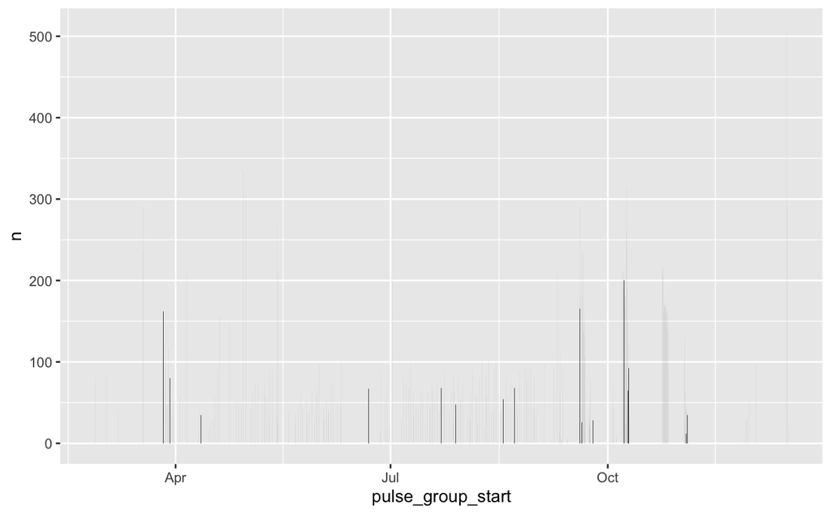

```r
# Visual time.
pulse_num %>%
  filter(!is.na(pulse_group)) %>%
  ggplot() +
    geom_bar(aes(x = pulse_group_start, y = n), stat = "identity")
```

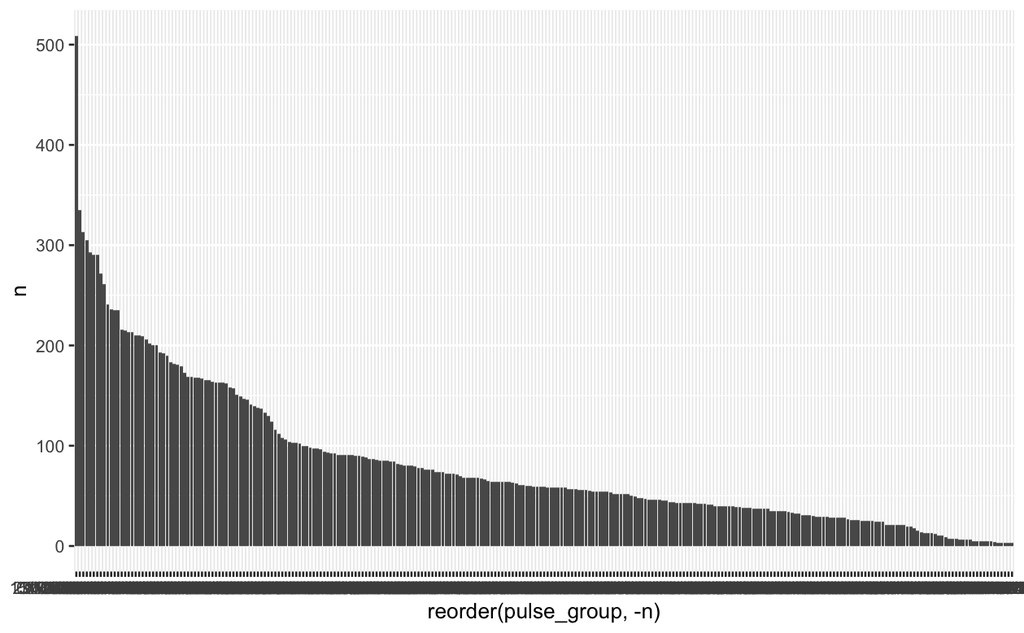

```r
# Visual magnitude
pulse_num %>%
  filter(!is.na(pulse_group)) %>%
  ggplot() +
    geom_bar(aes(x = reorder(pulse_group, -n), y = n), stat = "identity")
```

Check the numbers split by ferment

```r
# Data
(pulse_num_split <- df %>%
  group_by(ferment, ferment_bool, pulse_group) %>%
  count() %>%
  ungroup() %>%
  filter(!is.na(pulse_group)))

# Number of pulse periods ferment v non-ferment
pulse_num_split %>%
  group_by(ferment_bool) %>%
  count()

# Number of pulse periods per ferment group
pulse_num_split %>%
  group_by(ferment) %>%
  count()

# Average number of oscilations
pulse_num_split %>%
  group_by(ferment) %>%
  summarise(mean(n))
```

There were 205 pulse periods outside and 67 during fermentation. (KEY)

For each fermentation there are between 16 and 27 pulse periods. (KEY)

## Duration

How long are pulse cooling periods?

```r
# Data
(pulse_dur <- df %>%
  filter(pulse == "start" | pulse == "end") %>%
  select(time, pulse, pulse_group) %>%
  mutate(duration = ifelse(pulse == "start", as.numeric(lead(time) - time), NA)) %>%
  filter(!is.na(duration)))

# Sorted
pulse_dur %>%
  select(duration) %>%
  summary()

# Normal values
pulse_dur %>%
  arrange(desc(duration))

# Visual time
p <- pulse_dur %>%
  ggplot() +
    geom_bar(aes(x = time, y = duration), stat = "identity")

ggplotly(p)

# Visual magnitude
pulse_dur %>%
  ggplot() +
    geom_bar(aes(x = reorder(pulse_group, -duration), y = duration), stat = "identity")
```

About an hour in average, right skewed (outliers in the max direction) (KEY)

Note the outliers in December.

Let’s check the numbers split by ferment

```r
# Data
(pulse_dur_split <- df %>%
  filter(pulse == "start" | pulse == "end") %>%
  select(ferment_bool, ferment, time, pulse, pulse_group) %>%
  mutate(duration = ifelse(pulse == "start", as.numeric(lead(time) - time), NA)) %>%
  filter(!is.na(duration)) %>%
  select(ferment_bool, ferment, time, pulse_group, duration))

# Average duration ferment vs non-ferment
pulse_dur_split %>%
  group_by(ferment_bool) %>%
  summarise(duration_average= mean(duration))

# Average per fermentation state
pulse_dur_split %>%
  group_by(ferment) %>%
  summarise(duration_average= mean(duration))
```

Fermentation pulses are roughly double as long as non-fermentation pulses. (KEY)

The September fermentation pulses are the shortest, the late October pulses the longest.

This seems counterintuitive as the September fermentation was the most active

Let’s check the oscillations:

```r
# Data
(pulse_dur_split <- df %>%
  group_by(ferment, pulse_group) %>%
  count() %>%
  ungroup() %>%
  filter(!is.na(pulse_group)))

# Number of pulse periods
pulse_num_split %>%
  group_by(ferment) %>%
  count()

# Average number of oscilations
pulse_num_split %>%
  group_by(ferment) %>%
  summarise(mean(n))
```

The oscillations seem to follow the time. (more below)

## Rate of change

What is the rate of temperature change during pulse cooling?

First, we want to get a good data-frame that has deltas for all interesting measures (time, temp, pulse numbers, pulse duration) as well as the rate of change per hour.

```r
# Data
(df_pulse <- df %>%
  filter(pulse == "start" | pulse == "end") %>%
  select(time, ferment_bool, ferment, pulse, pulse_group, temp) %>%
  mutate(temp_diff = ifelse(pulse == "start", as.numeric(lead(temp) - temp), NA)) %>%
  mutate(pulse_duration = ifelse(pulse == "start", as.numeric(lead(time) - time), NA)) %>%
  filter(pulse == "start") %>%
  select(-pulse) %>%
  left_join(pulse_num %>% select(pulse_group, pulse_number = n), by = "pulse_group") %>%
  mutate(roc = temp_diff / (pulse_duration/60))) # temperature change per hour (pulse_duration is in minutes, hence /60 is in hours)
```

| time | ferment_bool | ferment | pulse_group | temp | temp_diff | pulse_duration | pulse_number | roc |
| --- | --- | --- | --- | --- | --- | --- | --- | --- |
| 2021-02-25 19:53:32 | FALSE | no-ferment | 25/02/2021 19:53 | 55.04572 | -0.98825455 | 74.100000 | 82 | -8.002061e-01 |
| 2021-03-02 14:41:42 | FALSE | no-ferment | 02/03/2021 14:41 | 54.95832 | -0.19073486 | 75.766667 | 81 | -1.510439e-01 |
| 2021-03-07 13:17:44 | FALSE | no-ferment | 07/03/2021 13:17 | 54.91328 | 0.09695816 | 38.033333 | 40 | 1.529577e-01 |
| 2021-03-17 23:51:54 | FALSE | no-ferment | 17/03/2021 23:51 | 55.10157 | -0.19179535 | 287.983333 | 290 | -3.995968e-02 |
| 2021-03-18 06:35:53 | FALSE | no-ferment | 18/03/2021 06:35 | 54.93819 | -0.28112792 | 231.983333 | 236 | -7.271072e-02 |
| 2021-03-25 21:36:00 | FALSE | no-ferment | 25/03/2021 21:36 | 54.92327 | 0.00000000 | 24.083333 | 26 | 0.000000e+00 |
| 2021-03-26 08:18:01 | FALSE | no-ferment | 26/03/2021 08:18 | 54.99586 | -0.03086471 | 103.966667 | 108 | -1.781227e-02 |
| 2021-03-26 14:38:00 | FALSE | no-ferment | 26/03/2021 14:38 | 54.95739 | 0.02886963 | 49.983333 | 52 | 3.465511e-02 |
| 2021-03-26 19:30:02 | FALSE | no-ferment | 26/03/2021 19:30 | 55.01279 | -0.19351960 | 151.950000 | 162 | -7.641445e-02 |
| 2021-03-27 12:43:59 | FALSE | no-ferment | 27/03/2021 12:43 | 54.95306 | -0.08244706 | 54.050000 | 57 | -9.152310e-02 |

[output cut: 259 more lines]

```r
NA
```

```r
(t <- df %>%
  filter(pulse == "start" | pulse == "end") %>%
  select(time, ferment_bool, ferment, pulse, pulse_group, temp) %>%
  mutate(temp_diff = ifelse(pulse == "start", as.numeric(lead(temp) - temp), NA)) %>%
  mutate(pulse_duration = ifelse(pulse == "start", as.numeric(lead(time) - time), NA)))
```

| time | ferment_bool | ferment | pulse | pulse_group | temp | temp_diff | pulse_duration |
| --- | --- | --- | --- | --- | --- | --- | --- |
| 2021-02-25 19:53:32 | FALSE | no-ferment | start | 25/02/2021 19:53 | 55.04572 | -0.98825455 | 74.100000 |
| 2021-02-25 21:07:38 | FALSE | no-ferment | end | 25/02/2021 19:53 | 54.05746 | NA | NA |
| 2021-03-02 14:41:42 | FALSE | no-ferment | start | 02/03/2021 14:41 | 54.95832 | -0.19073486 | 75.766667 |
| 2021-03-02 15:57:28 | FALSE | no-ferment | end | 02/03/2021 14:41 | 54.76758 | NA | NA |
| 2021-03-07 13:17:44 | FALSE | no-ferment | start | 07/03/2021 13:17 | 54.91328 | 0.09695816 | 38.033333 |
| 2021-03-07 13:55:46 | FALSE | no-ferment | end | 07/03/2021 13:17 | 55.01024 | NA | NA |
| 2021-03-17 23:51:54 | FALSE | no-ferment | start | 17/03/2021 23:51 | 55.10157 | -0.19179535 | 287.983333 |
| 2021-03-18 04:39:53 | FALSE | no-ferment | end | 17/03/2021 23:51 | 54.90978 | NA | NA |
| 2021-03-18 06:35:53 | FALSE | no-ferment | start | 18/03/2021 06:35 | 54.93819 | -0.28112792 | 231.983333 |
| 2021-03-18 10:27:52 | FALSE | no-ferment | end | 18/03/2021 06:35 | 54.65707 | NA | NA |

[output cut: 528 more lines]

```r
NA
```

```r
as.numeric(ymd_hms("2021-02-25 21:07:38") - ymd_hms("2021-02-25 19:53:32"))
```

```
[1] 1.235
```

```r
as.numeric(t[2,1] %>% pull() - t[1,1] %>% pull()) * 60
```

```
[1] 74.1
```

EDIT: we’ll remove two pulse_groups below when checking the pulse modulations (see headline *Modulations*)

### Frequencies

Now let’s look at frequencies and distributions

```r
# function.
show_frequencies <- function(var) {
  var_enquo <- enquo(var)

  p1 <- ggplot(df_pulse) +
    geom_bar(aes(x = pulse_group, y = !!var_enquo), stat = "identity") +
    facet_wrap(~ferment_bool)

  p2 <- ggplot(df_pulse) +
    geom_density(aes(x = !!var_enquo)) +
    # geom_histogram(aes(x = temp)) +
    facet_wrap(~ferment_bool)

  print(p1)
  print(p2)
}
```

```r
# Skims
print("non-ferment")
df_pulse %>%
  filter(!ferment_bool) %>%
  skimr::skim()

print("ferment")
df_pulse %>%
  filter(ferment_bool) %>%
  skimr::skim()

# Frequencies
show_frequencies(temp)
show_frequencies(temp_diff)

show_frequencies(pulse_duration)
show_frequencies(pulse_number)

show_frequencies(roc)
```

There’s some hefty positive ROC’s. Let’s see where they are:

```r
p <- ggplot(df_pulse) +
  geom_bar(aes(x = pulse_group, y = roc), stat = "identity") +
  facet_wrap(~ferment_bool)

ggplotly(p)
```

```r
ggplotly(chart_full_year)
```

The top positive ROC during non-fermentation is a very short pulse (possibly during an empty tank).

In general, all larger positive ROC’s happened during pulses shorter than 10 minutes: (KEY)

```r
# Show data
(roc_pos <- df_pulse %>%
  filter(roc > 0) %>%
  select(-time, -ferment_bool) %>%
  arrange(desc(roc)))

# Show scatter
p <- ggplot(roc_pos, aes(x = pulse_duration, y = roc)) +
  geom_point(aes(colour = roc))

ggplotly(p)
```

## Associations

First, let’s check all correlations - noting that `pulse_duration` v `temp_diff` will be the most interesting and telling.

```r
# Data
non_ferments <- df_pulse %>% filter(!ferment_bool)
ferments <- df_pulse %>% filter(ferment_bool)

# Correlation
cor(non_ferments %>% select(temp, temp_diff, pulse_duration, pulse_number, roc))
cor(ferments %>% select(temp, temp_diff, pulse_duration, pulse_number, roc))

# Plot
(t <- ferments %>% select(temp, temp_diff, pulse_duration, pulse_number, roc))
(p <- GGally::ggpairs(t))
ggplotly(p)
```

Correlation notes for fermentation:

- The higher the temp the higher the temp change (very weak)
- The higher the temp the shorter the pulse periods (medium)
- The higher the temp the fewer oscillations (medium)
- the higher the temp change the shorter the pulses (weak - medium)
- the higher the temp change the fewer the pulses (weak - medium)
- the longer the pulses the more oscillations (strong)
- the longer the pulse periods the smaller the ROC (weak)

In short:

- Higher temperatures seem to be best addressed by shorter pulses periods
- However, the more oscillations and the longer the pulses, the more negative the temperature change (which means the more efficient the pulsing). (REALLY?)

## Focus duration vs temperature change

So pulse duration has a weak to medium impact on temperature changes. Let’s look at this in more detail:

```r
p <- df_pulse %>%
  # filter(temp_diff < 0) %>%   2
  # filter(pulse_duration < 250) %>%
  ggplot(aes(x = pulse_duration, y = temp_diff, label = pulse_group)) +
    geom_point(aes(colour = ferment_bool)) +
    geom_smooth(method = "loess") +
    facet_wrap(~ ferment_bool, scales = "free_x")

ggplotly(p)
```

Non-fermentation (red) notes:

- Non-fermentation pulses are largely random. Take away the extremes and you have a random scatter
- The majority of non-fermentation pulses cluster around 0 degrees.
- It seems pulses need to be at least 40 minutes to reduce temperatures, but the duration can’t be the only impact here due to its randomness

Fermentation:

- The fermentation pulses tell a more pronounced association
- No major positive spikes during fermentation. Pulsing seems more focussed.
- Pulses shorter than 10-20 minutes tend to not have a cooling effect.
- The association shows two **distinct patterns**: (KEY)
  1. Pulses below ~85 minutes show a clear negative correlation to `temp_diff`
  2. Pulses above ~85 minutes are random wrt `temp_diff`

Does this differ across the three fermentations?

```r
# Full durations
p1 <- df_pulse %>%
  filter(ferment_bool) %>%
  ggplot(aes(x = pulse_duration, y = temp_diff, label = pulse_group)) +
    geom_point(aes(colour = ferment)) +
    geom_smooth(method = "loess") +
    # facet_wrap(~ ferment, scales = "free_x")
    facet_wrap(~ ferment) +
    labs(title = "Fermentation faceted by period | all durations")

# <= 85 minutes
p2 <- df_pulse %>%
  filter(ferment_bool) %>%
  filter(pulse_duration <= 85) %>%
  ggplot(aes(x = pulse_duration, y = temp_diff, label = pulse_group)) +
    geom_point(aes(colour = ferment)) +
    geom_smooth(method = "loess") +
    facet_wrap(~ ferment) +
    labs(title = "Fermentation faceted by period | <= 85 minutes")

# > 85 minutes
p3 <- df_pulse %>%
  filter(ferment_bool) %>%
  filter(pulse_duration > 85) %>%
  ggplot(aes(x = pulse_duration, y = temp_diff, label = pulse_group)) +
    geom_point(aes(colour = ferment)) +
    geom_smooth(method = "loess") +
    facet_wrap(~ ferment) +
    labs(title = "Fermentation faceted by period | > 85 minutes")

ggplotly(p1)
ggplotly(p2)
ggplotly(p3)
```

Fermentations 1 (Sep-09) and 2 (Oct-04) show the same pattern. Fermentation 3 (Oct-19) only has a single pulse period below 85 minutes.

But all three show a fairly random pattern for longer fermentations.

But we shouldn’t over-interpret. The gist is that most pulses during fermentation have a temperature reducing effects: (KEY)

```r
df_pulse %>%
  filter(ferment_bool) %>%
  mutate(temp_change = ifelse(temp_diff > 0, "positive", "negative")) %>%
  group_by(temp_change, ferment) %>%
  count()
```

The ones that don’t - tend to be short (under 20 min’s). (KEY)

Further we see that up to ~85 minute pulses the temperature reduction increases with increasing duration. Beyond 85 min’s the association seems random.

(Check series)

```r
ggplotly(chart_full_year)
```

## Rate of change during pulse

We have a couple of slices to look at:

- Fermentation vs non-fermentation
- Pulses that work (roc < 0) vs pulses that don’t work
- Each fermentation period

### Normal values

Describe the slices by their normal values

```r
# All
df_pulse %>%
  select(roc) %>%
  summary()

# Fermentation periods.
df_pulse %>%
  group_by(ferment) %>%
  summarise(
    min = min(roc),
    max = max(roc),
    median = median(roc),
    mean = mean(roc),
  )

# Fermentation periods and working pulses (< 0)
df_pulse %>%
  filter(roc < 0) %>%
  group_by(ferment) %>%
  summarise(
    min = min(roc),
    max = max(roc),
    median = median(roc),
    mean = mean(roc),
  )

# Boxplots.
df_pulse %>%
  filter(roc < 0) %>%
  ggplot() +
    geom_boxplot(aes(x = roc, y = ferment), outlier.shape = NA) +
    scale_x_continuous(limits = c(-1, 0)) +
    labs(title = "Comparing normal values across fermentation periods", subtitle = "ROC < 0, no outliers")
```

Focussing on the working pulses (ROC < 0) the no-fermentation-pulses have significantly less impact than fermentation pulses. (KEY)

### Duration and ROC

How does pulse duration impact on the ROC? This is striking and a variation of what we saw with the temperature change:

```r
df_pulse %>%
  filter(ferment_bool & roc < 0) %>%
  ggplot(aes(x = pulse_duration, y = roc)) +
    geom_point(aes(colour = ferment)) +
    facet_grid(~ ferment) +
    # geom_smooth(method = "lm")
    geom_smooth(method = "loess")
```

There appears to be a negative relation between the duration and the (negative) roc: increased duration decreases the ROC.

```r
df_pulse %>%
  filter(ferment_bool & roc < 0) %>%
  mutate(pulse_short = pulse_duration < 85) %>%
  ggplot(aes(x = pulse_duration, y = roc)) +
    geom_point(aes(colour = pulse_short)) +
    geom_smooth(method = "lm", aes(fill = pulse_short)) +
    facet_wrap(~ ferment)
```

Nope, there isn’t a clear pattern insisting on *clear associations of shorter pulses* and *no associations of longer pulses.* Based on these few data points it’s down to chance.

However, we might be able to say that the shorter and longer pulses have a significantly different impact on the ROC:

```r
# Function to show density (roughly normal?) and do a T-test to check mean difference:
get_t_test <- function(ferment_period) {
  # Data
  data <- df_pulse  %>%
    filter(ferment == ferment_period & roc < 0) %>%
    mutate(pulse_short = pulse_duration < 85)

  # Density chart
  p <- ggplot(data) +
    # geom_histogram(aes(x = roc)) +
    geom_density(aes(x = roc)) +
    facet_wrap(~ pulse_short)

  print(p)

  # T Test
  tryCatch(
    t.test(data %>% filter(pulse_short) %>% pull(roc), data %>% filter(!pulse_short) %>% pull(roc)),
    error = function(e) print(paste("Ferment period:", ferment_period, e))
  )
}
```

check it here:

```r
get_t_test("Sep-09")
get_t_test("Oct-04")
get_t_test("Oct-19")
```

And indeed - at least the Sep-09 and the Oct-04 fermentations show a sign. Difference between pulse duration smaller and greater than 85 minutes. (KEY)

## Modulations

- What is the modulation frequency during pulse cooling?
- Does it change and if so how?

```r
df_pulse
```

### Check uniformity

First thing, we should check is if there are notable frequency changes within pulse periods, or if the modulation is uniform.

Let’s check visually. We’re only doing this for the fermentation periods

```r
# Plot fermentation pulses.
p_ferm <- df %>%
  filter(!is.na(pulse), ferment_bool) %>%
  ggplot() +
    geom_line(aes(x = time, y = status)) +
    facet_wrap(~ pulse_group, scales = "free_x")

# Plot is too large to view in, so save.
ggsave(paste0(root_path,"/data/v3/pulse/pulse-modulations-fermentation.jpg"), p_ferm, height = 10000, width = 10000, units = "px")

# Plot non-fermentation pulses.
p_nonferm <- df %>%
  filter(!is.na(pulse), !ferment_bool)%>%
  ggplot() +
    geom_line(aes(x = time, y = status)) +
    facet_wrap(~ pulse_group, scales = "free_x")

ggsave(paste0(root_path,"/data/v3/pulse/pulse-modulations-non-fermentation.jpg"), p_nonferm, height = 10000, width = 10000, units = "px")
```

Visually, they appear to be homogeneous. (KEY)

There are some really short pulse-groups we can probably remove, but the general picture is one of uniform oscillations.

Let’s look at the short ones (only fermentation):

- 19/09/2021 12:16
- 23/09/2021 10:37

```r
df %>%
  filter(pulse_group == "19/09/2021 12:16" | pulse_group == "23/09/2021 10:37")
```

Let’s remove them from df_pulse:

Note, that I won’t remove the non-fermentation ones here (I wasn’t interested in them until later - and am now thinking, we should remove them in the analysis whenever it makes sense).

```r
(df_pulse <- df_pulse %>%
  filter(pulse_group != "19/09/2021 12:16" & pulse_group != "23/09/2021 10:37"))
```

Next, we should try and get a numeric summary of the variations..

```r
(df_modulation <- df %>%
  # filter(!is.na(pulse), ferment_bool) %>%
  filter(!is.na(pulse)) %>%
  mutate(
    status_diff_2 = ifelse(status == 2, diff, NA_real_),
    status_diff_3 = ifelse(status == 3, diff, NA_real_)
  ) %>%
  group_by(pulse_group) %>%
  summarise(
    pulse_dur_2_mean_sec = mean(status_diff_2, na.rm = TRUE),
    pulse_dur_3_mean_sec = mean(status_diff_3, na.rm = TRUE),
    pulse_duration_2 = sum(status_diff_2, na.rm = TRUE) / 60,
    pulse_duration_3 = sum(status_diff_3, na.rm = TRUE) / 60,
  ) %>%
  mutate(
    cooling_percent_mean = pulse_dur_3_mean_sec / (pulse_dur_2_mean_sec + pulse_dur_3_mean_sec),
    cooling_percent = pulse_duration_3 / (pulse_duration_2 + pulse_duration_3),
  ) %>%
  ungroup())
```

`pulse_duration_status_2_*` variables captures the time in seconds (mean) / minutes (sum) each pulse_group *doesn’t* cool

`pulse_duration_status_3_*` variables captures the time in seconds (mean) / minutes (sum) each pulse_group *does* cool

`cooling_duration_*` variables show the percentage of time the pulse group is cooling.

Let’s look at their distributions:

```r
skimr::skim(df_modulation)
df_modulation %>% ggplot() + geom_density(aes(cooling_percent_mean))
df_modulation %>% ggplot() + geom_density(aes(cooling_percent_sum))
```

### Add modulations to df_pulse

Let’s join them with df_pulse.

As a side-note, there are 2 pulses in the modulation frame compared to df_pulse (the latter two I’ve just removed):

```r
one <- df_modulation %>% pull(pulse_group)
two <- df_pulse %>% pull(pulse_group)

(not_in_pulse <- df_modulation %>% filter(!one %in% two))
```

…we won’t add them back to df_pulse.

Join the data:

```r
# Check
df_pulse %>%
  left_join(df_modulation, by = "pulse_group") %>%
  # filter(ferment_bool) %>%
  mutate(check = pulse_duration - pulse_duration_2_sum - pulse_duration_3_sum) %>%
  arrange(desc(check))
  # arrange(check)

# Do
(df_pulse <- df_pulse %>%
  left_join(df_modulation, by = "pulse_group") %>%
  select(
    time,
    ferment_bool,
    ferment,
    pulse_group,
    temp,
    temp_diff,
    pulse_duration,
    roc,
    pulse_dur_2_mean_sec,
    pulse_dur_3_mean_sec,
    cooling_percent,
    pulse_duration_2,
    pulse_duration_3,
    pulse_number,
  ))
```

### Frequencies

Normal values:

```r
df_pulse %>%
  select(starts_with("pulse"), cooling_percent) %>%
  skimr::skim()
```

Some notes regarding modulations during fermentation: (KEY)

- An average pulse period is 77 minutes long - 62 of which are non-cooling, 16 of which are cooling (right skewed with high outliers).
- In average 17% of each pulse period is cooling = 83% non-cooling
- The average duration of an individual cooling section is 19 seconds
- The average duration of an individual non-cooling section is 95 seconds.

Looking at cooling percentages across the fermentation periods shows similar distributions with different gaps:

```r
# Data
df_pulse %>%
  filter(ferment_bool) %>%
  arrange(desc(cooling_percent))

# Density
df_pulse %>%
  filter(ferment_bool) %>%
  ggplot() +
    geom_density(aes(x = cooling_percent))

# Frequencies
df_pulse %>%
  filter(ferment_bool) %>%
  ggplot() +
    geom_bar(aes(x = reorder(pulse_group, -cooling_percent), y = cooling_percent, fill = ferment), stat = "identity") +
    facet_wrap(~ ferment)
```

```r
(p <- df_pulse %>%
  filter(ferment_bool) %>%
  ggplot(aes(x = cooling_percent, y = roc)) +
    geom_point() +
    geom_smooth(method = "lm"))

plotly::ggplotly(p)

df_pulse %>%
  filter(ferment_bool) %>%
  select(roc, cooling_percent, pulse_dur_2_mean_sec, pulse_dur_3_mean_sec) %>%
  GGally::ggpairs()
```

There’s no association between cooling percent and the rate of change.

In other words modulation can be chosen based on economic benefits (within the given range of modulation) (KEY)